# Logistic Regression

Ho Duc Ninh

# 1 Logistic Regression

## 1.1 Introduction

- Logistic regression or logit regression is a regression model where the dependent variable (DV) is categorical. Binary logistic regression is a type of regression analysis where the dependent variable is a dummy variable (coded 0, 1).
- Logistic regression is used when analyzing whether some event occurred or not, such as voting, participation in a public program, business success or failure, mortality, a hurricane and etc.

## 1.2 Logistic model

- Same spirit as linear regression
- Desired interpretation: probability to belong to a specific class for the specified inputs. The target value belongs to [0;1].
- Logistic function:
  $$Logit(p) = Ln(odds) = ln(\frac{p}{1-p}) = \alpha + \sum_{i=1}^n \beta_iX_i$$
  Or:
  $$f(t) = \frac{1}{( 1+ e^{-t})}$$
- Fitting : Find the estimates that max the likehood of obtaining the training sample.

# 2 An illustration for logistic regression

## 2.1 Objective

Analyse the probability of default using the the expalining variables

## 2.2 The dataset

The dataset has 4 variables, which are:

- Default: Whether the customer has actually defaulted or not(binary variable)
- Student: Whether he/she is a student (binary variable)
- Balance: Monthly credit card balance
- Income: Annual income

## 2.3 Data exploration

Let’s see the summary of the dataset

```r
data <- Default
data %>% str
```

```
## 'data.frame':    10000 obs. of  4 variables:
##  $ default: Factor w/ 2 levels "No","Yes": 1 1 1 1 1 1 1 1 1 1 ...
##  $ student: Factor w/ 2 levels "No","Yes": 1 2 1 1 1 2 1 2 1 1 ...
##  $ balance: num  730 817 1074 529 786 ...
##  $ income : num  44362 12106 31767 35704 38463 ...
```

```r
data %>% summary()
```

```
##  default    student       balance           income
##  No :9667   No :7056   Min.   :   0.0   Min.   :  772
##  Yes: 333   Yes:2944   1st Qu.: 481.7   1st Qu.:21340
##                        Median : 823.6   Median :34553
##                        Mean   : 835.4   Mean   :33517
##                        3rd Qu.:1166.3   3rd Qu.:43808
##                        Max.   :2654.3   Max.   :73554
```

```r
data %>%
  group_by(default) %>%
  summarise(mean_bal = mean(balance),
            quantile_50_bal = quantile(balance, 0.5),
            mean_inc = mean(income),
            quantile_50_inc=quantile(income,0.5))
```

```
## # A tibble: 2 × 5
##   default  mean_bal quantile_50_bal mean_inc quantile_50_inc
##    <fctr>     <dbl>           <dbl>    <dbl>           <dbl>
## 1      No  803.9438        802.8571 33566.17        34589.49
## 2     Yes 1747.8217       1789.0934 32089.15        31515.34
```

The first glance:

- There is a notable difference in the mean of balance account of those who defaulted and those who did not.

Let’s also see the plot of annual incomes and monthly credit card balances of individuals

The individuals who defaulted on their credit card payments are shown in blue, those who did not are shown in red.

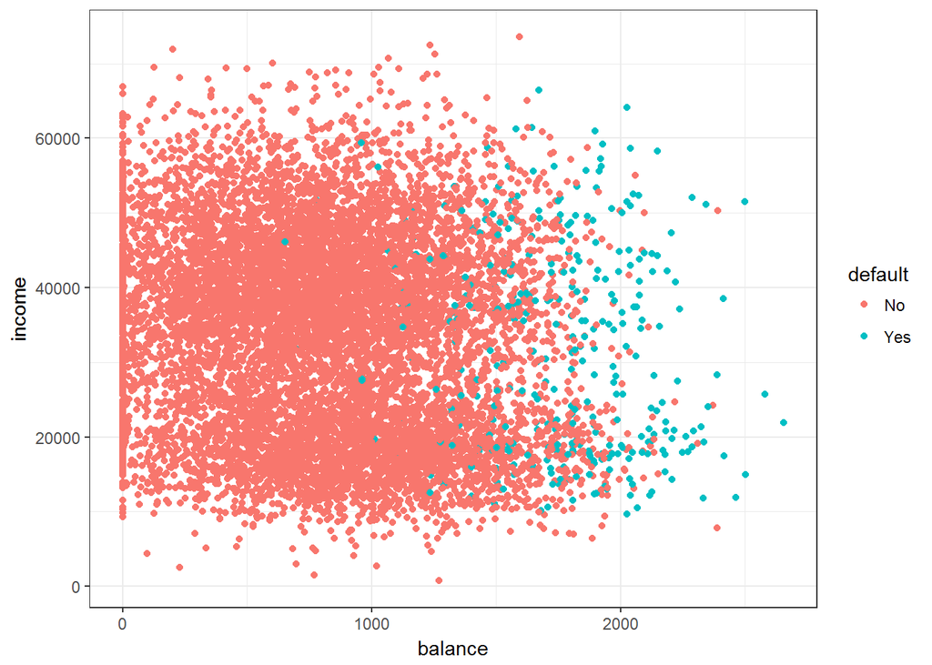

```r
ggplot(Default, aes(balance, income)) +
 geom_jitter(aes(color=default)) +
 theme_bw()
```

From the scatter plot, we can easily see that those have large balance are highly likely to be defaulted. Regarding to income aspect, the difference between groups is not clear.

We will examine the differences in terms of balance and income of the two groups of individuals.

With respect to monthly credit card balance:

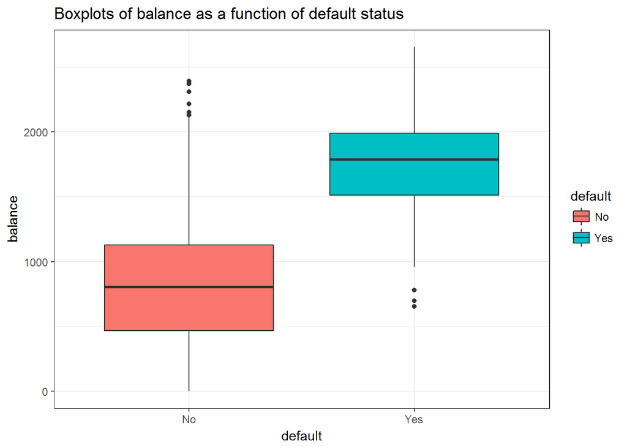

```r
ggplot(Default, aes(default,balance)) +
  geom_boxplot(aes(fill = default)) +
  ggtitle("Boxplots of balance as a function of default status") +
  theme_bw()
```

The plot shows that, there is a significant difference in the monthly balance of those who defaulted and did not default

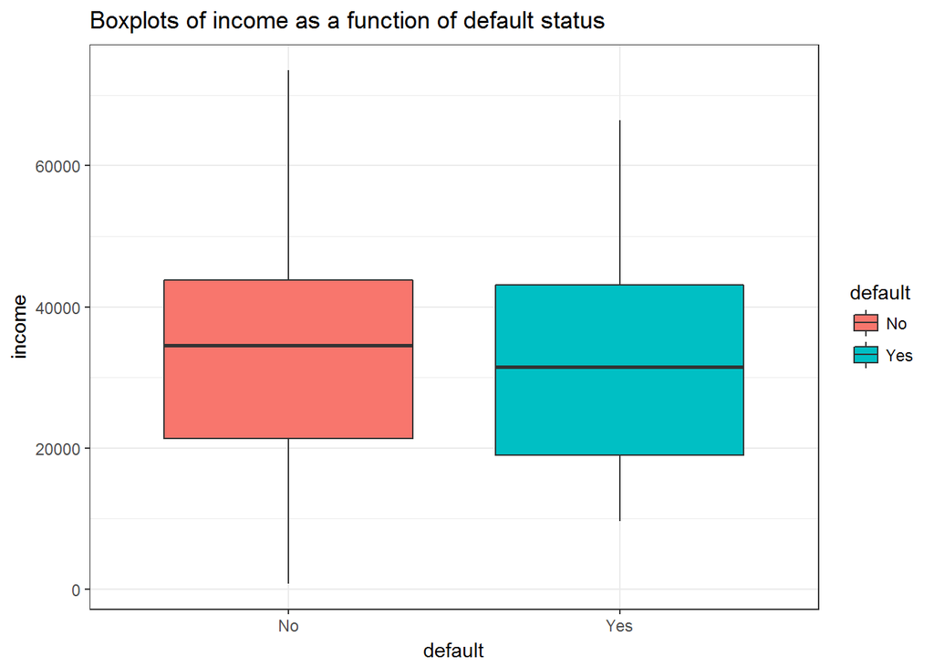

```r
ggplot(Default, aes(default,income)) +
  geom_boxplot(aes(fill = default)) +
  ggtitle("Boxplots of income as a function of default status") +
  theme_bw()
```

```r
aov(income ~ default , data = data) %>% TukeyHSD
```

```
##   Tukey multiple comparisons of means
##     95% family-wise confidence level
##
## Fit: aov(formula = income ~ default, data = data)
##
## $default
##            diff      lwr       upr     p adj
## Yes-No -1477.02 -2933.87 -20.16875 0.0469121
```

There is a slight difference between income of those people who defaulted and did not default.

## 2.4 Logistic model

### 2.4.1 Get the train and test set

We will build model on train test and test the fitted model on test set.

```r
bound <- floor((nrow(data)/4)*3)         # define % of training and test set
df <- data[sample(nrow(data)), ]         # sample rows
train <- data[1:bound, ]              # get training set
test <- data[(bound+1):nrow(df), ]    # get test set
```

We set the train and test set which account for 75 and 25 percent of total sample respectively.

### 2.4.2 Logistic regression on training set

Using logistic regression to predict default = Yes using balance, income and student status.

```r
lr.fit <- glm(default ~ balance +
                        income +
                        student,
            data = train,
            family = binomial())
summary(lr.fit)
```

```
##
## Call:
## glm(formula = default ~ balance + income + student, family = binomial(),
##     data = train)
##
## Deviance Residuals:
##     Min       1Q   Median       3Q      Max
## -2.1972  -0.1396  -0.0538  -0.0190   3.7065
##
## Coefficients:
##               Estimate Std. Error z value Pr(>|z|)
## (Intercept) -1.118e+01  5.811e-01 -19.232   <2e-16 ***
## balance      5.888e-03  2.739e-04  21.499   <2e-16 ***
## income       6.131e-06  9.655e-06   0.635   0.5254
## studentYes  -6.128e-01  2.783e-01  -2.202   0.0277 *
## ---
## Signif. codes:  0 '***' 0.001 '**' 0.01 '*' 0.05 '.' 0.1 ' ' 1
##
## (Dispersion parameter for binomial family taken to be 1)
##
##     Null deviance: 2219.0  on 7499  degrees of freedom
## Residual deviance: 1175.5  on 7496  degrees of freedom
## AIC: 1183.5
##
## Number of Fisher Scoring iterations: 8
```

### 2.4.3 Assessing the predictive ability of the model

In the steps above, In the steps above, we briefly evaluated the fitting of the model, now we would like to see how the model is doing when predicting y on a new set of data. Our decision boundary will be 0.5. If
$$P(y =1|X) > 0.5$$
then y=1 otherwise y=0.

```r
predTst <- predict(lr.fit, test, type = "response")

glm.pred <- rep("No", 2500)

glm.pred[predTst > .5] <- "Yes"

cTab <- table(glm.pred, test$default  , dnn=c("actual", "predicted") )

addmargins(cTab)
```

```
##       predicted
## actual   No  Yes  Sum
##    No  2410   50 2460
##    Yes   11   29   40
##    Sum 2421   79 2500
```

```r
fitted.results <- ifelse(predTst > 0.5,1,0)

misClasificError <- mean(fitted.results !=test$default)

print(paste('Accuracy', 0.9756))
```

```
## [1] "Accuracy 0.9756"
```

The 0.98 accuracy on the test set is quite a good result.

# 3 Performance of the model

## 3.1 Plot the ROC curve on train and test set

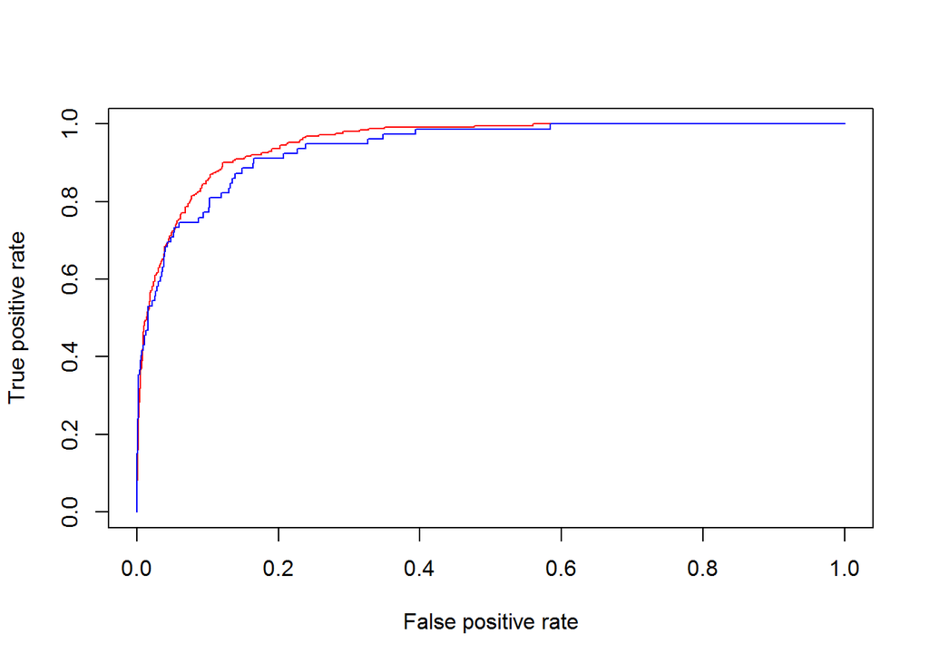

```r
# ROC curve on train test and test set
pred_output <- predict(lr.fit,train, type ="response")

predTst <- predict(lr.fit, test, type = "response")

ROCpred_train <- prediction(pred_output, train$default)

ROCpred_test <- prediction(predTst, test$default)

ROCperf_train <- performance(ROCpred_train, "tpr","fpr")

ROCperf_test <- performance(ROCpred_test, "tpr","fpr")

plot(ROCperf_train, col = "red")

plot(ROCperf_test, col = "blue", add =T)
```

## 3.2 Plot the GAIN curve on train and test set

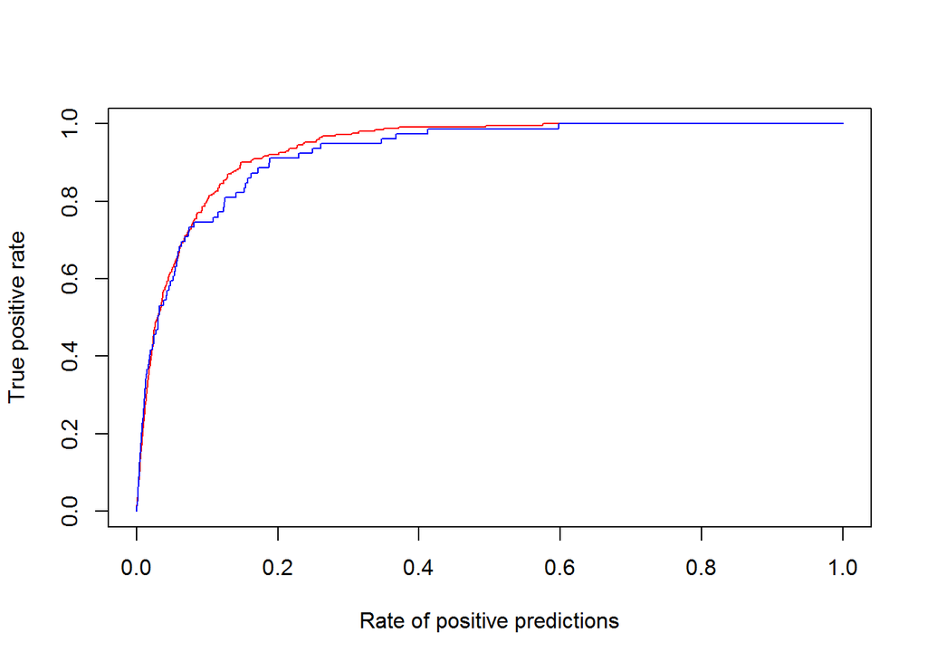

```r
# GAIN curve on train test

GAINperf_train <- performance(ROCpred_train, "tpr","rpp")

GAINperf_test <- performance(ROCpred_test, "tpr","rpp")

plot(GAINperf_train, col = "red")

plot(GAINperf_test, col = "blue", add =T)
```

## 3.3 Plot the Lift curve on train and test set

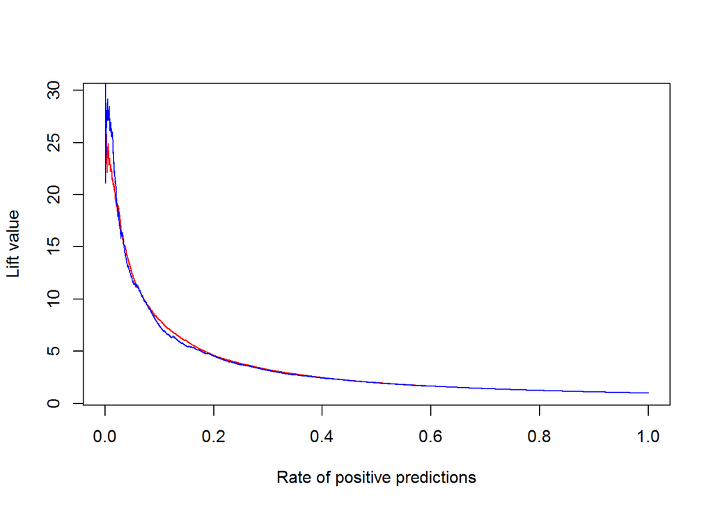

```r
# Lift curve

LIFTperf_train <- performance(ROCpred_train, "lift","rpp")

LIFTperf_test <- performance(ROCpred_test, "lift","rpp")

plot(LIFTperf_train, col = "red")

plot(LIFTperf_test, col = "blue", add =T)
```

# Logistic Regression

Ho Duc Ninh

# 1 Logistic Regression

## 1.1 Introduction

- Logistic regression or logit regression is a regression model where the dependent variable (DV) is categorical. Binary logistic regression is a type of regression analysis where the dependent variable is a dummy variable (coded 0, 1).
- Logistic regression is used when analyzing whether some event occurred or not, such as voting, participation in a public program, business success or failure, mortality, a hurricane and etc.

## 1.2 Logistic model

- Same spirit as linear regression
- Desired interpretation: probability to belong to a specific class for the specified inputs. The target value belongs to [0;1].
- Logistic function:
  $$Logit(p) = Ln(odds) = ln(\frac{p}{1-p}) = \alpha + \sum_{i=1}^n \beta_iX_i$$
  Or:
  $$f(t) = \frac{1}{( 1+ e^{-t})}$$
- Fitting : Find the estimates that max the likehood of obtaining the training sample.

# 2 An illustration for logistic regression

## 2.1 Objective

Analyse the probability of default using the the expalining variables

## 2.2 The dataset

The dataset has 4 variables, which are:

- Default: Whether the customer has actually defaulted or not(binary variable)
- Student: Whether he/she is a student (binary variable)
- Balance: Monthly credit card balance
- Income: Annual income

## 2.3 Data exploration

Let’s see the summary of the dataset

```r
data <- Default
data %>% str
```

```
## 'data.frame':    10000 obs. of  4 variables:
##  $ default: Factor w/ 2 levels "No","Yes": 1 1 1 1 1 1 1 1 1 1 ...
##  $ student: Factor w/ 2 levels "No","Yes": 1 2 1 1 1 2 1 2 1 1 ...
##  $ balance: num  730 817 1074 529 786 ...
##  $ income : num  44362 12106 31767 35704 38463 ...
```

```r
data %>% summary()
```

```
##  default    student       balance           income
##  No :9667   No :7056   Min.   :   0.0   Min.   :  772
##  Yes: 333   Yes:2944   1st Qu.: 481.7   1st Qu.:21340
##                        Median : 823.6   Median :34553
##                        Mean   : 835.4   Mean   :33517
##                        3rd Qu.:1166.3   3rd Qu.:43808
##                        Max.   :2654.3   Max.   :73554
```

```r
data %>%
  group_by(default) %>%
  summarise(mean_bal = mean(balance),
            quantile_50_bal = quantile(balance, 0.5),
            mean_inc = mean(income),
            quantile_50_inc=quantile(income,0.5))
```

```
## # A tibble: 2 × 5
##   default  mean_bal quantile_50_bal mean_inc quantile_50_inc
##    <fctr>     <dbl>           <dbl>    <dbl>           <dbl>
## 1      No  803.9438        802.8571 33566.17        34589.49
## 2     Yes 1747.8217       1789.0934 32089.15        31515.34
```

The first glance:

- There is a notable difference in the mean of balance account of those who defaulted and those who did not.

Let’s also see the plot of annual incomes and monthly credit card balances of individuals

The individuals who defaulted on their credit card payments are shown in blue, those who did not are shown in red.

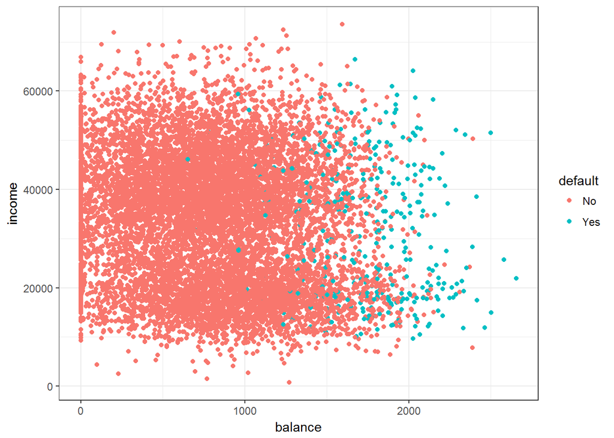

```r
ggplot(Default, aes(balance, income)) +
 geom_jitter(aes(color=default)) +
 theme_bw()
```

From the scatter plot, we can easily see that those have large balance are highly likely to be defaulted. Regarding to income aspect, the difference between groups is not clear.

We will examine the differences in terms of balance and income of the two groups of individuals.

With respect to monthly credit card balance:

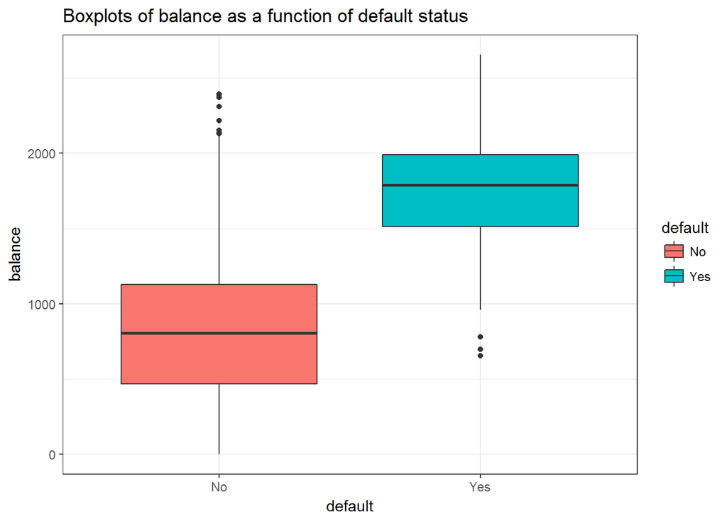

```r
ggplot(Default, aes(default,balance)) +
  geom_boxplot(aes(fill = default)) +
  ggtitle("Boxplots of balance as a function of default status") +
  theme_bw()
```

The plot shows that, there is a significant difference in the monthly balance of those who defaulted and did not default

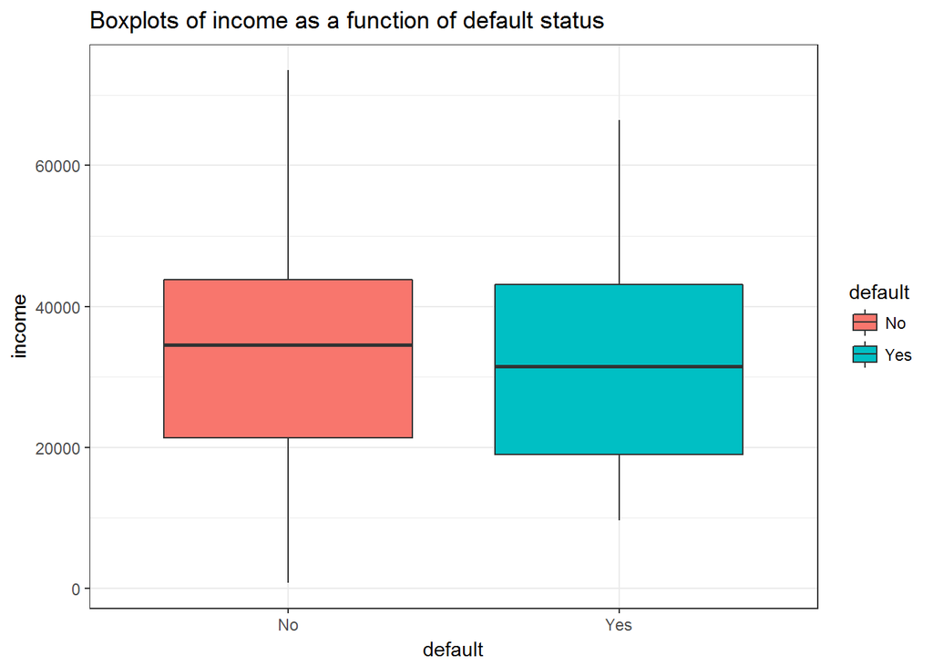

```r
ggplot(Default, aes(default,income)) +
  geom_boxplot(aes(fill = default)) +
  ggtitle("Boxplots of income as a function of default status") +
  theme_bw()
```

```r
aov(income ~ default , data = data) %>% TukeyHSD
```

```
##   Tukey multiple comparisons of means
##     95% family-wise confidence level
##
## Fit: aov(formula = income ~ default, data = data)
##
## $default
##            diff      lwr       upr     p adj
## Yes-No -1477.02 -2933.87 -20.16875 0.0469121
```

There is a slight difference between income of those people who defaulted and did not default.

## 2.4 Logistic model

### 2.4.1 Get the train and test set

We will build model on train test and test the fitted model on test set.

```r
bound <- floor((nrow(data)/4)*3)         # define % of training and test set
df <- data[sample(nrow(data)), ]         # sample rows
train <- data[1:bound, ]              # get training set
test <- data[(bound+1):nrow(df), ]    # get test set
```

We set the train and test set which account for 75 and 25 percent of total sample respectively.

### 2.4.2 Logistic regression on training set

Using logistic regression to predict default = Yes using balance, income and student status.

```r
lr.fit <- glm(default ~ balance +
                        income +
                        student,
            data = train,
            family = binomial())
summary(lr.fit)
```

```
##
## Call:
## glm(formula = default ~ balance + income + student, family = binomial(),
##     data = train)
##
## Deviance Residuals:
##     Min       1Q   Median       3Q      Max
## -2.1972  -0.1396  -0.0538  -0.0190   3.7065
##
## Coefficients:
##               Estimate Std. Error z value Pr(>|z|)
## (Intercept) -1.118e+01  5.811e-01 -19.232   <2e-16 ***
## balance      5.888e-03  2.739e-04  21.499   <2e-16 ***
## income       6.131e-06  9.655e-06   0.635   0.5254
## studentYes  -6.128e-01  2.783e-01  -2.202   0.0277 *
## ---
## Signif. codes:  0 '***' 0.001 '**' 0.01 '*' 0.05 '.' 0.1 ' ' 1
##
## (Dispersion parameter for binomial family taken to be 1)
##
##     Null deviance: 2219.0  on 7499  degrees of freedom
## Residual deviance: 1175.5  on 7496  degrees of freedom
## AIC: 1183.5
##
## Number of Fisher Scoring iterations: 8
```

### 2.4.3 Assessing the predictive ability of the model

In the steps above, In the steps above, we briefly evaluated the fitting of the model, now we would like to see how the model is doing when predicting y on a new set of data. Our decision boundary will be 0.5. If
$$P(y =1|X) > 0.5$$
then y=1 otherwise y=0.

```r
predTst <- predict(lr.fit, test, type = "response")

glm.pred <- rep("No", 2500)

glm.pred[predTst > .5] <- "Yes"

cTab <- table(glm.pred, test$default  , dnn=c("actual", "predicted") )

addmargins(cTab)
```

```
##       predicted
## actual   No  Yes  Sum
##    No  2410   50 2460
##    Yes   11   29   40
##    Sum 2421   79 2500
```

```r
fitted.results <- ifelse(predTst > 0.5,1,0)

misClasificError <- mean(fitted.results !=test$default)

print(paste('Accuracy', 0.9756))
```

```
## [1] "Accuracy 0.9756"
```

The 0.98 accuracy on the test set is quite a good result.

# 3 Performance of the model

## 3.1 Plot the ROC curve on train and test set

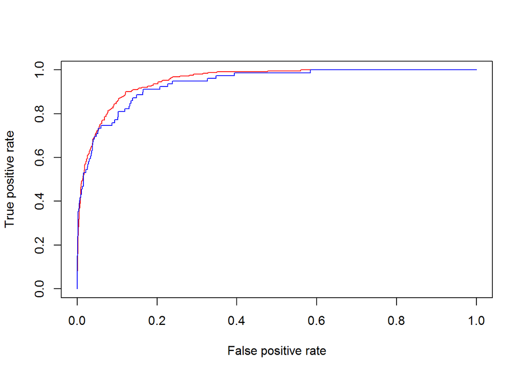

```r
# ROC curve on train test and test set
pred_output <- predict(lr.fit,train, type ="response")

predTst <- predict(lr.fit, test, type = "response")

ROCpred_train <- prediction(pred_output, train$default)

ROCpred_test <- prediction(predTst, test$default)

ROCperf_train <- performance(ROCpred_train, "tpr","fpr")

ROCperf_test <- performance(ROCpred_test, "tpr","fpr")

plot(ROCperf_train, col = "red")

plot(ROCperf_test, col = "blue", add =T)
```

## 3.2 Plot the GAIN curve on train and test set

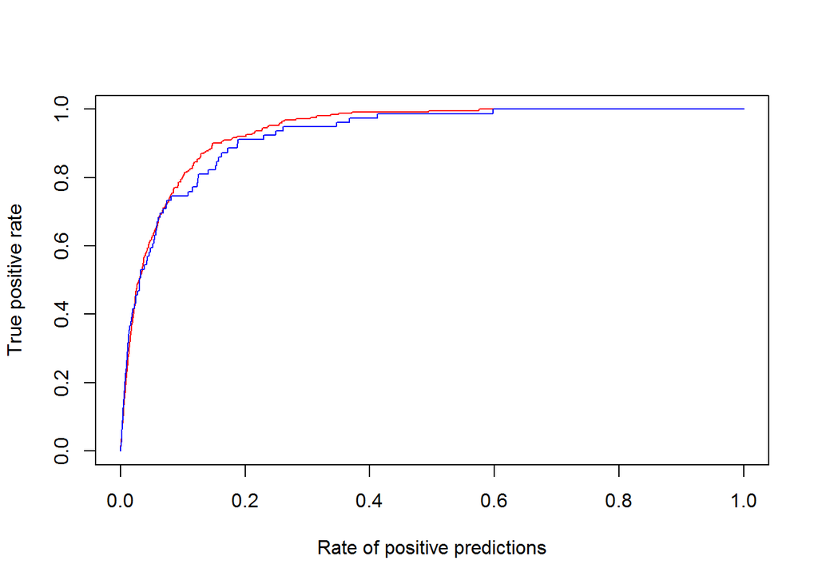

```r
# GAIN curve on train test

GAINperf_train <- performance(ROCpred_train, "tpr","rpp")

GAINperf_test <- performance(ROCpred_test, "tpr","rpp")

plot(GAINperf_train, col = "red")

plot(GAINperf_test, col = "blue", add =T)
```

## 3.3 Plot the Lift curve on train and test set

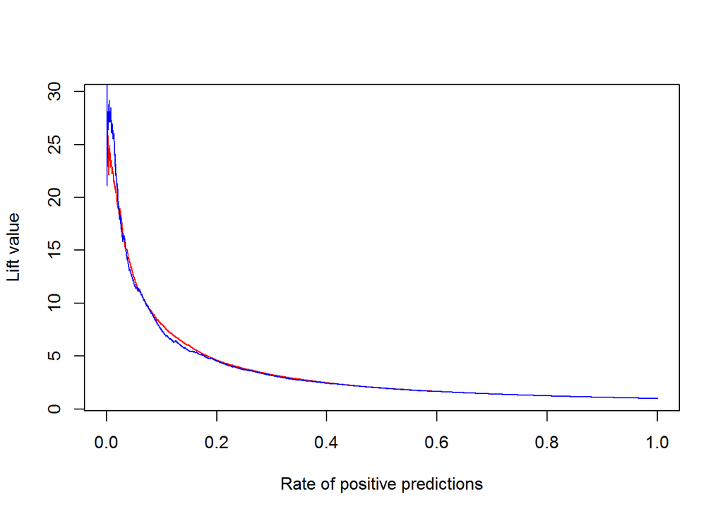

```r
# Lift curve

LIFTperf_train <- performance(ROCpred_train, "lift","rpp")

LIFTperf_test <- performance(ROCpred_test, "lift","rpp")

plot(LIFTperf_train, col = "red")

plot(LIFTperf_test, col = "blue", add =T)
```